# main

## 1. Business Understanding

This project will analyze customer reviews of Amazon's electronic products to identify the key drivers of customer satisfaction and dissatisfaction. By understanding what customers love and hate about our products, we can provide actionable insights to:

- **Product Development:** Pinpoint specific features that need improvement and identify new features that customers desire.
- **Marketing:** Craft more effective marketing messages that highlight the features customers love the most.
- **Quality Assurance:** Identify products with recurring quality issues.

The ultimate goal is to improve product quality, increase customer satisfaction, and boost sales.

## 2. Data Understanding

I chose to use [Consumer Reviews of Amazon Products](https://www.kaggle.com/datasets/datafiniti/consumer-reviews-of-amazon-products) from Kaggle because it contains a lot of the review from the customers. It also contain some important features, such as categories of the product, manufaturer of the product and the rating, which is really helpful for sentiment analytics and further exploration. Unfortunately, after examining this dataset, it only contains review which related to technical product, and only include the product manufactured by Amazon, I think it'll be the biggest hindrance when using this dataset for analyze

### Import for datas preprossing and EDA

```python
import kagglehub
import pandas as pd
import numpy as np
import os
import re
from nltk.corpus import stopwords
from collections import Counter

import plotly.graph_objects as go
from wordcloud import WordCloud
import matplotlib.pyplot as plt
from IPython.display import Image
```

```python
path = kagglehub.dataset_download("datafiniti/consumer-reviews-of-amazon-products")
df1 = pd.read_csv(os.path.join(path, '1429_1.csv'), low_memory=False)
df2 = pd.read_csv(os.path.join(path, 'Datafiniti_Amazon_Consumer_Reviews_of_Amazon_Products_May19.csv'))
df3 = pd.read_csv(os.path.join(path, 'Datafiniti_Amazon_Consumer_Reviews_of_Amazon_Products.csv'))
```

The original dataset from Kaggle is divided into three separate csv files, after concate it, it include the following features and information. Here is a quick overview:

```python
master_df = pd.concat([df1, df2, df3], ignore_index=True)
master_df.to_csv('amazon_reviews_master.csv')
master_df.info()
master_df.isna().sum()
```

```
<class 'pandas.core.frame.DataFrame'>
RangeIndex: 67992 entries, 0 to 67991
Data columns (total 27 columns):
 #   Column                Non-Null Count  Dtype
---  ------                --------------  -----
 0   id                    67992 non-null  object
 1   name                  61232 non-null  object
 2   asins                 67990 non-null  object
 3   brand                 67992 non-null  object
 4   categories            67992 non-null  object
 5   keys                  67992 non-null  object
 6   manufacturer          67992 non-null  object
 7   reviews.date          67953 non-null  object
 8   reviews.dateAdded     25091 non-null  object
 9   reviews.dateSeen      67992 non-null  object
```

[output cut: 19 more lines]

```
id                          0
name                     6760
asins                       2
brand                       0
categories                  0
keys                        0
manufacturer                0
reviews.date               39
reviews.dateAdded       42901
reviews.dateSeen            0
reviews.didPurchase     67982
reviews.doRecommend     12840
reviews.id              67921
reviews.numHelpful      12746
reviews.rating             33
reviews.sourceURLs          0
reviews.text                1
reviews.title              19
reviews.userCity        67992
reviews.userProvince    67992
reviews.username           13
dateAdded               34660
dateUpdated             34660
primaryCategories       34660
imageURLs               34660
manufacturerNumber      34660
sourceURLs              34660
dtype: int64
```

We can see all the columns and their missing values in the result above

### 3. Data Preparation & Exploratory Data Analysis (EDA)

```python
master_df.isna().sum()
master_df.duplicated().sum()
```

```
np.int64(95)
```

#### - Drop unrelated features and duplicate values

```python
df_cleaned = master_df.copy()
```

```python
df_cleaned.drop_duplicates(subset=['reviews.username', 'reviews.text', 'reviews.rating'], inplace=True)
```

```python
# Define the columns to drop
columns_to_drop = [
    'reviews.userCity',
    'reviews.userProvince',
    'reviews.id',
    'reviews.didPurchase',
    'reviews.dateAdded',
    'id',
    'asins',
    'keys',
    'manufacturer',
    'reviews.sourceURLs',
    'sourceURLs',
    'imageURLs',
    'manufacturerNumber',
    'dateAdded',
    'dateUpdated'
]

df_cleaned.drop(columns=columns_to_drop, inplace=True)
```

#### - Drop missing value & change the data type

```python
df_cleaned.dropna(subset=['reviews.rating', 'reviews.text', 'reviews.title', 'reviews.username', 'reviews.date', 'reviews.doRecommend'], inplace=True)
df_cleaned['primaryCategories'] = df_cleaned['primaryCategories'].fillna('Unknown')
df_cleaned['name'] = df_cleaned['name'].fillna('Unknown')
df_cleaned['reviews.date'] = pd.to_datetime(df_cleaned['reviews.date'], errors='coerce')
df_cleaned['reviews.rating'] = df_cleaned['reviews.rating'].astype(int)
df_cleaned['reviews.numHelpful'] = df_cleaned['reviews.numHelpful'].fillna(0).astype(int)


df_cleaned.info()
df_cleaned.isna().sum()
```

```
<class 'pandas.core.frame.DataFrame'>
Index: 37297 entries, 0 to 66412
Data columns (total 12 columns):
 #   Column               Non-Null Count  Dtype
---  ------               --------------  -----
 0   name                 37297 non-null  object
 1   brand                37297 non-null  object
 2   categories           37297 non-null  object
 3   reviews.date         37297 non-null  datetime64[ns, UTC]
 4   reviews.dateSeen     37297 non-null  object
 5   reviews.doRecommend  37297 non-null  object
 6   reviews.numHelpful   37297 non-null  int64
 7   reviews.rating       37297 non-null  int64
 8   reviews.text         37297 non-null  object
 9   reviews.title        37297 non-null  object
 10  reviews.username     37297 non-null  object
 11  primaryCategories    37297 non-null  object
dtypes: datetime64[ns, UTC](1), int64(2), object(9)
memory usage: 3.7+ MB
```

```
name                   0
brand                  0
categories             0
reviews.date           0
reviews.dateSeen       0
reviews.doRecommend    0
reviews.numHelpful     0
reviews.rating         0
reviews.text           0
reviews.title          0
reviews.username       0
primaryCategories      0
dtype: int64
```

#### - Review text Cleaning for sentiment analysis

```python
stop_words = set(stopwords.words('english'))

def clean_text(text):
    text = str(text)
    text = text.lower()
    text = re.sub(r'[^\w\s]', '', text)
    text = re.sub(r'\d+', '', text)
    text = " ".join(word for word in text.split() if word not in stop_words)
    return text

df_cleaned['reviews.text_cleaned'] = df_cleaned['reviews.text'].apply(clean_text)
df_cleaned['reviews.title_cleaned'] = df_cleaned['reviews.title'].apply(clean_text)
```

#### Fig1. Distribution of Customer Ratings

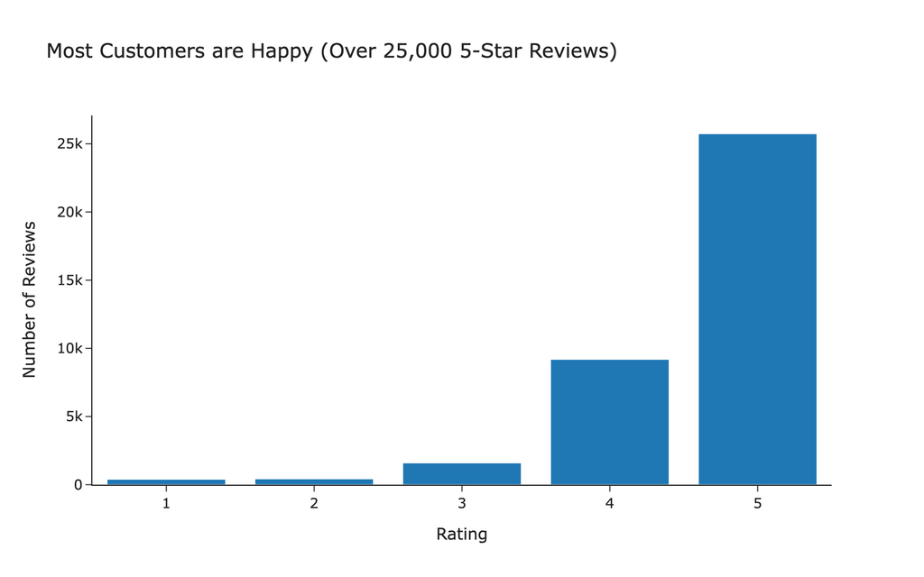

```python
rating_counts = Counter(df_cleaned['reviews.rating'])
ratings = sorted(rating_counts.keys())
counts = [rating_counts[rating] for rating in ratings]

fig1 = go.Figure(data=[go.Bar(x=ratings, y=counts)])

fig1.update_layout(
    title='Most Customers are Happy (Over 25,000 5-Star Reviews)',
    xaxis_title='Rating',
    yaxis_title='Number of Reviews',
    xaxis=dict(tickmode='linear'),

    width=800,
    height=500,
    template='simple_white'
)
fig1.write_image("fig1.png", scale=3)
Image("fig1.png", width=800)
```

- The first chart shows that almost everyone loves these products. The bar for 5-star reviews is huge (over 25,000), way more than all the other ratings combined.
- This shows that, in general, customers are super happy. But it also means I should probably pay extra attention to the few 1-star and 2-star reviews, since they're so different from the norm.

#### Fig2. Average Customer Rating Over Time

[figure not shown]

```python
df_cleaned['reviews.date'] = pd.to_datetime(df_cleaned['reviews.date'])

df_cleaned['month_year'] = df_cleaned['reviews.date'].dt.tz_localize(None).dt.to_period('M')
monthly_ratings = df_cleaned.groupby('month_year')['reviews.rating'].mean().reset_index()
monthly_ratings = monthly_ratings.sort_values('month_year')

monthly_ratings['month_year'] = monthly_ratings['month_year'].dt.to_timestamp()

fig2 = go.Figure(data=[go.Scatter(x=monthly_ratings['month_year'], y=monthly_ratings['reviews.rating'], mode='lines')])

fig2.update_layout(
    title="1-Star Reviews are Voted 'Most Helpful' by Shoppers",
    xaxis_title='Date',
    yaxis_title='Average Rating',
    width=800,
    height=500,
    template='simple_white'
)
fig2.write_image("fig2.png", scale=5)
Image("fig2.png", width=800)
```

- Overall, average customer ratings remain high, consistently staying above 4.3 stars. This reinforces our finding that most customers are highly satisfied.
- There was a severe drop in customer satisfaction in the second half of 2015, with average ratings plummeting from 4.8 to below 4.4. This is a major red flag. This trend reversed in early 2016, followed by a slow, steady 2-year recovery.
- We see a massive spike in satisfaction in mid 2018, with ratings hitting a perfect 5.0 before becoming more volatile. This spike likely corresponds to a very successful new product launch.

#### Fig3. Word Cloud of Reviews

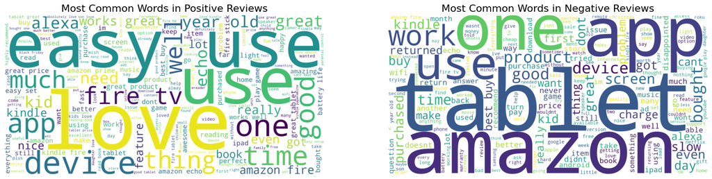

```python
positive_reviews = df_cleaned[df_cleaned['reviews.rating'].isin([4, 5])]['reviews.text_cleaned']
negative_reviews = df_cleaned[df_cleaned['reviews.rating'].isin([1, 2])]['reviews.text_cleaned']

positive_text = ' '.join(positive_reviews)
negative_text = ' '.join(negative_reviews)

wordcloud_positive = WordCloud(width=1600, height=800, background_color='white'
).generate(positive_text)
wordcloud_negative = WordCloud(width=1600, height=800, background_color='white'
).generate(negative_text)

plt.figure(figsize=(20, 10))

plt.subplot(1, 2, 1)
plt.imshow(wordcloud_positive, interpolation='bilinear')
plt.title('Most Common Words in Positive Reviews', fontsize=16)
plt.axis('off')

plt.subplot(1, 2, 2)
plt.imshow(wordcloud_negative, interpolation='bilinear')
plt.title('Most Common Words in Negative Reviews', fontsize=16)
plt.axis('off')

plt.savefig("fig3.png", dpi=1200, bbox_inches='tight')

plt.show()
```

- In Positive Reviews: The biggest words are love, easy, use, and device.
- In Negative Reviews: The word tablet is massive. Other big words are app, problem, and work.
- It looks like people are happiest when the product is just easy to use. The negative reviews suggest that the tablets are the main source of problems, probably related to apps not working right or the device itself breaking.

#### Fig4. Average "Helpful" Votes by Star Rating

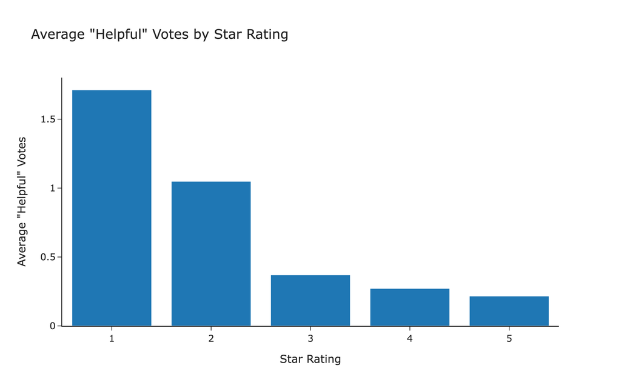

```python
helpfulness_by_rating = df_cleaned.groupby('reviews.rating')['reviews.numHelpful'].mean().reset_index()

fig4 = go.Figure(data=[
    go.Bar(
        x=helpfulness_by_rating['reviews.rating'],
        y=helpfulness_by_rating['reviews.numHelpful']
    )
])

fig4.update_layout(
    title='Average "Helpful" Votes by Star Rating',
    xaxis_title='Star Rating',
    yaxis_title='Average "Helpful" Votes',
    width=800,
    height=500,
    template='simple_white'
)


fig4.write_image("fig4.png", scale=5)

Image("fig4.png", width=800)
```

- This chart was really surprising. 1-star reviews get an average of 1.75 helpful votes, which is way more than any other rating. 2-star reviews are the second most helpful.
- This shows that people actually find the negative reviews more helpful when they're deciding what to buy. It's a big deal because it means the company should really be reading and replying to those 1-star reviews.

#### Fig5. Review Length vs. Star Rating

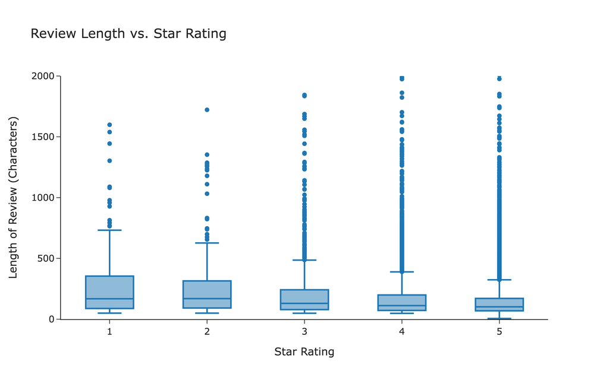

```python
df_cleaned['review_length'] = df_cleaned['reviews.text'].str.len()

fig5 = go.Figure(data=[
    go.Box(
        x=df_cleaned['reviews.rating'],
        y=df_cleaned['review_length']
    )
])

fig5.update_layout(
    title='Review Length vs. Star Rating',
    xaxis_title='Star Rating',
    yaxis_title='Length of Review (Characters)',
    width=800,
    height=500,
    template='simple_white'
)


fig5.update_yaxes(range=[0, 2000])
fig5.write_image("fig5.png", scale=5)
Image("fig5.png", width=800)
```

- I made a boxplot to see if angry people write more, and they do. The "box" for 1-star and 2-star reviews is higher up, meaning their typical review length is longer than for 3, 4, or 5-star reviews.
- Those dots are outliers (some people write a lot), but the main takeaway is that negative reviews are usually more detailed. People aren't just saying "it's bad"; they're explaining why it's bad, which is really useful data for the company to find and fix bugs.

## 4. Modeling

### Business Problem:

- The main goal is to identify the sentiment of review text. It's a binary classification task, the result will be either negative (0) or positive (1).
- In order to do that, I define 1 to 2 star rating as negative, 4 to 5 star rating as positive. After examing the dataset, I decide to drop all the 3 star rating data, because it only represents a small portion of data.

### Model Selection

I choose to use those model to solve the classification problem and also compare the results of them to see which one has better accuracy score and ability to handle dataset imbalance. Due to the negative review is more important than the positive review, I'll focus more on the macro f1 score of negative review when evaluate the models

- Multinomial Naive Bayes: a fast, famously model for text classification
- Logistic Regression: a common baseline for classification problem
- Linear SVC: a classification model for high-dimensional text
- LSTM: a deep learning model that understands word order and context

#### Import for building models & Preprocssing

```python
from sklearn.model_selection import train_test_split, RandomizedSearchCV
from sklearn.pipeline import Pipeline
from sklearn.feature_extraction.text import TfidfVectorizer
from sklearn.preprocessing import MaxAbsScaler
from sklearn.naive_bayes import MultinomialNB
from sklearn.linear_model import LogisticRegression
from sklearn.svm import LinearSVC
from sklearn.metrics import classification_report, confusion_matrix, ConfusionMatrixDisplay, make_scorer, f1_score

from imblearn.pipeline import Pipeline as ImbPipeline
from imblearn.over_sampling import SMOTE

import tensorflow as tf
from tensorflow.keras.preprocessing.text import Tokenizer
from tensorflow.keras.preprocessing.sequence import pad_sequences
from tensorflow.keras.models import Sequential
from tensorflow.keras.layers import Input, Embedding, LSTM, Dense, Dropout, Bidirectional
from tensorflow.keras import layers
import keras_tuner as kt
from tensorflow import keras


import warnings
warnings.filterwarnings('ignore', category=UserWarning)
```

```python
df_model = df_cleaned[df_cleaned['reviews.rating'] != 3].copy()
df_model['sentiment'] = df_model['reviews.rating'].apply(lambda x: 1 if x >= 4 else 0)
X = df_model['reviews.text_cleaned']
y = df_model['sentiment']

X_train, X_test, y_train, y_test = train_test_split(X, y, test_size=0.2, random_state=42, stratify=y)
```

#### Baseline Model 1: Multinomial Naive Bayes

```python
pipeline_nb = Pipeline([
    ('tfidf', TfidfVectorizer(max_features=5000)),
    ('clf', MultinomialNB())
])

pipeline_nb.fit(X_train, y_train)
y_pred_nb = pipeline_nb.predict(X_test)

print("\n--- Multinomial Naive Bayes Report ---")
print(classification_report(y_test, y_pred_nb))
```

```
--- Multinomial Naive Bayes Report ---
              precision    recall  f1-score   support

           0       1.00      0.01      0.01       160
           1       0.98      1.00      0.99      6982

    accuracy                           0.98      7142
   macro avg       0.99      0.50      0.50      7142
weighted avg       0.98      0.98      0.97      7142
```

- **Result**: The model failed with **0.01** f1-score, the macro score is **0.5** showcasing that this data can't handle data imbalance

#### Baseline Model 2: Logistic Regression

```python
pipeline_lr = Pipeline([
    ('tfidf', TfidfVectorizer(max_features=5000)),
    ('clf', LogisticRegression(class_weight='balanced', random_state=42, solver='liblinear'))
])


pipeline_lr.fit(X_train, y_train)
y_pred_lr = pipeline_lr.predict(X_test)

print("\n--- Logistic Regression Report ---")
print(classification_report(y_test, y_pred_lr))
```

```
--- Logistic Regression Report ---
              precision    recall  f1-score   support

           0       0.22      0.70      0.33       160
           1       0.99      0.94      0.97      6982

    accuracy                           0.94      7142
   macro avg       0.60      0.82      0.65      7142
weighted avg       0.98      0.94      0.95      7142
```

- **Result**: with the class_weight parameter, the f1-score is **0.33**, the macro f1-score is **0.65**, but still need to be improved

#### Baseline Model 3: Linear SVC

```python
pipeline_svc = Pipeline([
    ('tfidf', TfidfVectorizer(max_features=5000)),
    ('scaler', MaxAbsScaler()),
    ('clf', LinearSVC(class_weight='balanced', random_state=42, max_iter=2000))
])

pipeline_svc.fit(X_train, y_train)
y_pred_svc = pipeline_svc.predict(X_test)

print("\n--- Linear SVC Report ---")
print(classification_report(y_test, y_pred_svc))
```

```
--- Linear SVC Report ---
              precision    recall  f1-score   support

           0       0.26      0.50      0.34       160
           1       0.99      0.97      0.98      6982

    accuracy                           0.96      7142
   macro avg       0.62      0.73      0.66      7142
weighted avg       0.97      0.96      0.96      7142
```

- **Result**: The linear SVC has an F1-score of **0.34** for the negative class, with a macro F1-score of **0.66**

#### Baseline Model 4: LSTM

```python
MAX_VOCAB_SIZE = 10000
MAX_LENGTH = 200
EMBEDDING_DIM = 100
NUM_EPOCHS = 5
BATCH_SIZE = 64


tokenizer = Tokenizer(num_words=MAX_VOCAB_SIZE, oov_token='<OOV>')
tokenizer.fit_on_texts(X_train)

X_train_padded = pad_sequences(tokenizer.texts_to_sequences(X_train), maxlen=MAX_LENGTH, padding='post', truncating='post')
X_test_padded = pad_sequences(tokenizer.texts_to_sequences(X_test), maxlen=MAX_LENGTH, padding='post', truncating='post')

total = len(y_train)
pos = np.sum(y_train)
neg = total - pos
weight_for_0 = (1 / neg) * (total / 2.0)
weight_for_1 = (1 / pos) * (total / 2.0)
class_weights = {0: weight_for_0, 1: weight_for_1}

y_train_array = np.asarray(y_train)
```

```python
def create_lstm_model(embedding_dim, lstm_units_1, lstm_units_2, dropout_rate, learning_rate):

    model = Sequential([


        Input(shape=(MAX_LENGTH,), name='input_layer'),


        Embedding(input_dim=MAX_VOCAB_SIZE, output_dim=embedding_dim, name='embedding'),


        Bidirectional(LSTM(lstm_units_1, return_sequences=True), name='bilstm_1'),
        Bidirectional(LSTM(lstm_units_2), name='bilstm_2'),


        Dropout(dropout_rate, name='dropout'),


        Dense(1, activation='sigmoid', name='output')
    ])


    model.compile(
        loss='binary_crossentropy',
        optimizer=keras.optimizers.Adam(learning_rate=learning_rate),
        metrics=['accuracy', tf.keras.metrics.AUC(name='auc')] # Add AUC here too
    )

    return model
```

```python
baseline_model = create_lstm_model(
    embedding_dim=EMBEDDING_DIM, # This was 100
    lstm_units_1=64,
    lstm_units_2=32,
    dropout_rate=0.5,
    learning_rate=1e-3 # Default 'adam' lr is 0.001
)
baseline_model.summary()

print("\nTraining Baseline LSTM...")
history = baseline_model.fit(X_train_padded, y_train,
                    epochs=NUM_EPOCHS,
                    batch_size=BATCH_SIZE,
                    validation_data=(X_test_padded, y_test),
                    class_weight=class_weights)
```

```
Model: "sequential_1"
```

```
┏━━━━━━━━━━━━━━━━━━━━━━━━━━━━━━━━━┳━━━━━━━━━━━━━━━━━━━━━━━━┳━━━━━━━━━━━━━━━┓
┃ Layer (type)                    ┃ Output Shape           ┃       Param # ┃
┡━━━━━━━━━━━━━━━━━━━━━━━━━━━━━━━━━╇━━━━━━━━━━━━━━━━━━━━━━━━╇━━━━━━━━━━━━━━━┩
│ embedding (Embedding)           │ (None, 200, 100)       │     1,000,000 │
├─────────────────────────────────┼────────────────────────┼───────────────┤
│ bilstm_1 (Bidirectional)        │ (None, 200, 128)       │        84,480 │
├─────────────────────────────────┼────────────────────────┼───────────────┤
│ bilstm_2 (Bidirectional)        │ (None, 64)             │        41,216 │
├─────────────────────────────────┼────────────────────────┼───────────────┤
│ dropout (Dropout)               │ (None, 64)             │             0 │
├─────────────────────────────────┼────────────────────────┼───────────────┤
│ output (Dense)                  │ (None, 1)              │            65 │
└─────────────────────────────────┴────────────────────────┴───────────────┘
```

```
 Total params: 1,125,761 (4.29 MB)
```

```
 Trainable params: 1,125,761 (4.29 MB)
```

```
 Non-trainable params: 0 (0.00 B)
```

```
Training Baseline LSTM...
447/447 ━━━━━━━━━━━━━━━━━━━━ 95s 206ms/step - accuracy: 0.7952 - auc: 0.8487 - loss: 0.4881 - val_accuracy: 0.9343 - val_auc: 0.9263 - val_loss: 0.1800
447/447 ━━━━━━━━━━━━━━━━━━━━ 96s 215ms/step - accuracy: 0.9174 - auc: 0.9535 - loss: 0.2639 - val_accuracy: 0.8582 - val_auc: 0.9328 - val_loss: 0.3604
447/447 ━━━━━━━━━━━━━━━━━━━━ 96s 214ms/step - accuracy: 0.9412 - auc: 0.9740 - loss: 0.1856 - val_accuracy: 0.9495 - val_auc: 0.9160 - val_loss: 0.1425
447/447 ━━━━━━━━━━━━━━━━━━━━ 98s 220ms/step - accuracy: 0.9657 - auc: 0.9828 - loss: 0.1313 - val_accuracy: 0.9378 - val_auc: 0.9063 - val_loss: 0.1797
447/447 ━━━━━━━━━━━━━━━━━━━━ 98s 218ms/step - accuracy: 0.9725 - auc: 0.9886 - loss: 0.1054 - val_accuracy: 0.9458 - val_auc: 0.8981 - val_loss: 0.1652
```

```python
y_pred_probs = baseline_model.predict(X_test_padded)
y_pred_lstm = np.where(y_pred_probs > 0.5, 1, 0)
print("\n--- Baseline LSTM Model Final Report ---")
print(classification_report(y_test, y_pred_lstm, target_names=['Negative', 'Positive']))
```

```
224/224 ━━━━━━━━━━━━━━━━━━━━ 7s 30ms/step

--- Baseline LSTM Model Final Report ---
              precision    recall  f1-score   support

    Negative       0.23      0.59      0.33       160
    Positive       0.99      0.95      0.97      6982

    accuracy                           0.95      7142
   macro avg       0.61      0.77      0.65      7142
weighted avg       0.97      0.95      0.96      7142
```

### Tuning Model

Because Naive Bayes can't be hyper parameter tuned, so I skip the tuning process of it in this step

#### 1. Tuned Logistic Regression

This tuning pipeline includes SMOTE, an oversampling technique used to fix the class imbalance in the training data.

```python
f1_macro_scorer = make_scorer(f1_score, average='macro')
pipe_smote_lr = ImbPipeline([
    ('tfidf', TfidfVectorizer()),
    ('smote', SMOTE(random_state=42)),
    ('model', LogisticRegression(solver='liblinear', max_iter=1000))
])

param_grid_smote_lr = {
    'model__C': [0.1, 1, 10, 100],
    'model__penalty': ['l1', 'l2'],
    'smote__k_neighbors': [3, 5, 7, 10],
    'tfidf__ngram_range': [(1, 1), (1, 2)],
}

random_search_smote_lr = RandomizedSearchCV(
    estimator=pipe_smote_lr,
    param_distributions=param_grid_smote_lr,
    n_iter=10,
    cv=5,
    scoring=f1_macro_scorer,
    n_jobs=-1,
    random_state=42
)


random_search_smote_lr.fit(X_train, y_train)


print(f"Best macro F1-score: {random_search_smote_lr.best_score_:.4f}")
```

```
Best macro F1-score: 0.7489
```

- **Result**: We can see that the macro f1 score increased to **0.7489**.

#### 2. Tuned LinearSVC

```python
pipe_svc = Pipeline([
    ('tfidf', TfidfVectorizer(max_features=5000)),
    ('scaler', MaxAbsScaler()),
    ('svc', LinearSVC(class_weight='balanced', random_state=42, max_iter=2000))
])

param_grid_svc = {
    'svc__C': [0.1, 1, 10],
    'svc__penalty': ['l2'],
    'svc__class_weight': [None, 'balanced'],
    'tfidf__ngram_range': [(1, 1), (1, 2)],
}

f1_macro_scorer = make_scorer(f1_score, average='macro')

SVC_tuned = RandomizedSearchCV(
    estimator=pipe_svc,
    param_distributions=param_grid_svc,
    n_iter=10,
    cv=5,
    scoring=f1_macro_scorer,
    n_jobs=-1,
    random_state=42
)

SVC_tuned.fit(X_train, y_train)

print(f"Best macro F1-score of SVC: {SVC_tuned.best_score_:.4f}")
```

```
Best macro F1-score of SVC: 0.7015
```

- **Result**: The score from **0.66** to **0.7015**, showcasing the model has much better ability after tuning.

### 3. Tuned LSTM

```python
def build_model_for_tuner(hp):


    hp_embedding_dim = hp.Int('embedding_dim', min_value=64, max_value=128, step=32)
    hp_lstm_units_1 = hp.Int('lstm_units_1', min_value=32, max_value=64, step=32)
    hp_lstm_units_2 = hp.Int('lstm_units_2', min_value=16, max_value=32, step=16)
    hp_dropout = hp.Float('dropout', min_value=0.3, max_value=0.5, step=0.1)


    hp_learning_rate = hp.Choice('learning_rate', values=[1e-3, 1e-4])


    model = create_lstm_model(
        embedding_dim=hp_embedding_dim,
        lstm_units_1=hp_lstm_units_1,
        lstm_units_2=hp_lstm_units_2,
        dropout_rate=hp_dropout,
        learning_rate=hp_learning_rate
    )

    return model
```

```python
print("\n--- Starting LSTM Hyperparameter Search ---")
tuner = kt.RandomSearch(
    build_model_for_tuner,
    objective=kt.Objective('val_auc', direction='max'),
    max_trials=5,
    executions_per_trial=1,
    directory='lstm_tuning',
    project_name='customer_analytics_v4'
)

tuner.search(
    X_train_padded,
    y_train_array,
    epochs=5,
    validation_split=0.2,
    class_weight=class_weights
)
```

```
--- Starting LSTM Hyperparameter Search ---
Reloading Tuner from lstm_tuning/customer_analytics_v4/tuner0.json
```

```python
print("\n--- Evaluating Tuned LSTM ---")
best_lstm_model = tuner.get_best_models(num_models=1)[0]
y_pred_probs_tuned = best_lstm_model.predict(X_test_padded)
y_pred_lstm_tuned = np.where(y_pred_probs_tuned > 0.5, 1, 0)

print("\n--- Tuned LSTM Model Final Report ---")
print(classification_report(y_test, y_pred_lstm_tuned, target_names=['Negative', 'Positive']))
```

```
--- Evaluating Tuned LSTM ---
224/224 ━━━━━━━━━━━━━━━━━━━━ 6s 27ms/step

--- Tuned LSTM Model Final Report ---
              precision    recall  f1-score   support

    Negative       0.24      0.66      0.36       160
    Positive       0.99      0.95      0.97      6982

    accuracy                           0.95      7142
   macro avg       0.62      0.80      0.66      7142
weighted avg       0.98      0.95      0.96      7142
```

## 5. Evaluation

```
--- Final Model Evaluation ---
              precision    recall  f1-score   support

    Negative       0.41      0.56      0.47       160
    Positive       0.99      0.98      0.99      6982

    accuracy                           0.97      7142
   macro avg       0.70      0.77      0.73      7142
weighted avg       0.98      0.97      0.97      7142
```

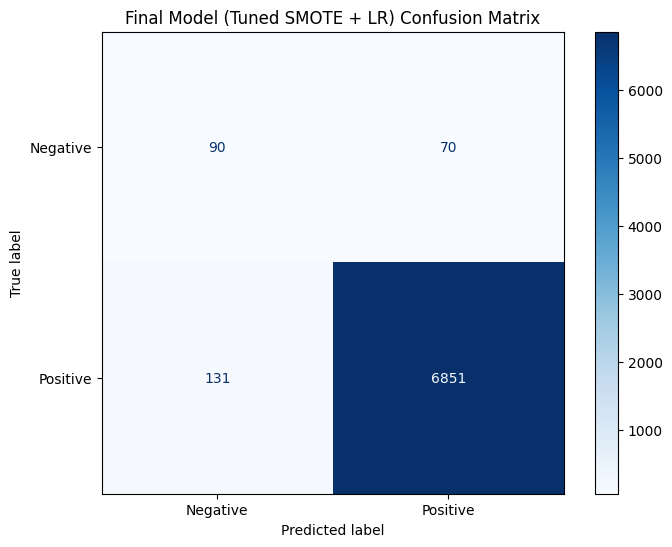

```python
final_model = random_search_smote_lr.best_estimator_


y_pred_final = final_model.predict(X_test)


print("--- Final Model Evaluation ---")
print(classification_report(y_test, y_pred_final, labels=[0, 1], target_names=['Negative', 'Positive']))

cm_final = confusion_matrix(y_test, y_pred_final)
disp_final = ConfusionMatrixDisplay(confusion_matrix=cm_final, display_labels=['Negative', 'Positive'])

fig, ax = plt.subplots(figsize=(8, 6))


disp_final.plot(ax=ax, cmap='Blues')

ax.set_title('Final Model (Tuned SMOTE + LR) Confusion Matrix')


plt.savefig("fig6.png", dpi=300, bbox_inches='tight')

plt.show()
```

**Technical Performance**:

**Translating Results to Business Impact**:

- We can now automatically identify **56%** of all incoming negative reviews. The model can catch over half of our angry customers, allowing the support team to intervene.
- Although the model flags a review as negative, but only gets it correct 41% of the time. While the other 59% are false positives, this is a very low business cost, it only takes a support agent a few seconds to read and discard a false alarm.

## 6. Summary

This project analyzed over 37,000 customer reviews to identify the key drivers of customer satisfaction and dissatisfaction.

The analysis of the data (EDA) revealed that while overall satisfaction is extremely high, the small number of 1-star and 2-star reviews are voted "most helpful" by other shoppers. This means these negative reviews have a disproportionately large impact on new customers.

To find the root cause, I built and tuned a machine learning model to classify review text. The final Tuned Logistic Regression (with SMOTE) model is a major success. It can now automatically identify 56% of all incoming negative reviews, allowing for proactive customer intervention.

The key findings are:

- Satisfaction is driven by usability: Customers are happiest when the product is **easy** to use, **great** for their **kids**, and they **love** it.
- Dissatisfaction is driven by product failure. Customers are most dissatisfied due to specific product issues such as **tablet**, **battery** and **screen**.

Recommendation:

1. For the Product & QA Team: Investigate the **tablet** product line. The high frequency of **tablet**, **battery** and **screen** as negative drivers strongly suggests a recurring quality control or hardware issue that must be addressed.
2. For the Marketing Team: Leverage the top positive-driver words. Marketing campaigns should heavily feature messaging around the products being **easy to use** and **perfect for kids**, as this language clearly resonates with our most satisfied customers.
3. For the Customer Support Team: Deploy this model as a real-time triage tool. All reviews flagged as **negative** should be routed to a special queue for a fast, public response. Since the result of EDA shows the negative reviews are the most helpful and most read.

What If & Next Steps

- If I can had access to product SKUs (Stock Keeping Unit), I could link these **tablet** reviews to a specific model instead of a general category. I could also build a model to predict which reviews are most likely to lead to a costly product return.
- Next Steps: The clear next step is to improve this model's low precision score.
  - Adjust decision threshold from default 0.5 to 0.6 or 0.7, increase the precision score.
  - Implement ADASYN (Advanced SMOTE) to prevent over-sampling.
  - Change **f1_macro** to **precision_macro** when re-running the hyperparameter tuning to increase the precision score.